# Ann Arbor Climate Extremes

Kiera Matiska

2023-04-15

## Read in Data

```r
climate_clean <- read_csv(here("data", "A2_climate_data.csv")) %>%
  clean_names()

climate <- climate_clean %>%
  mutate(date = ymd(date)) %>%
  mutate(year = substr(date, 1, 4)) %>%
  mutate(month = substr(date, 6, 7)) %>%
  mutate(day = substr(date, 9, 10)) %>%
  mutate(season = case_when(
    month == "01" ~ "winter",
    month == "02" ~ "winter",
    month == "03" ~ "winter",
    month == "04" ~ "spring",
    month == "05" ~ "spring",
    month == "06" ~ "spring",
    month == "07" ~ "summer",
    month == "08" ~ "summer",
    month == "09" ~ "summer",
    month == "10" ~ "fall",
    month == "11" ~ "fall",
    month == "12" ~ "fall"
  ))
```

The temperature range in Ann Arbor, MI is normally 17°F to 84°F. I am going to use those two numbers, anything below the low and above the high, for my extremes analysis. Any day that has precipitation - including both rain or snow - above 1.25” is likely to have a large flood event.

# Extreme Metrics

## Temperature

### Extreme Cold Days

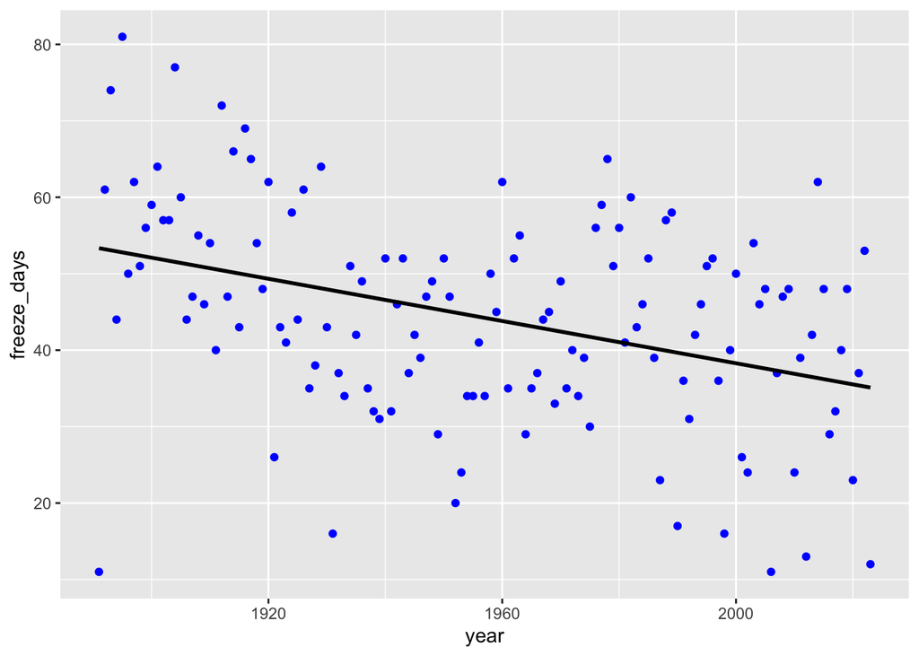

```r
climate$freeze <- ifelse(climate$tmin <= 17, 1, 0)

clim_fr_sum <- climate %>%
  group_by(year) %>%
  summarize(freeze_days = sum(freeze)) %>%
  mutate(year = as.numeric(year))

ggplot(data = clim_fr_sum,
       aes(x = year, y = freeze_days)) +
  geom_point(color = "blue") +
  geom_smooth(formula = y ~ x,
              color = "black",
              method = "lm",
              se = FALSE)
```

```r
freeze_lm <- lm(freeze_days ~ year, data = clim_fr_sum)
```

The y-intercept value stands at 314.54 days. The slope for freeze days per year is -0.138 and is statistically significant with a p-value of 5.82e-06.

### Extreme Hot Days

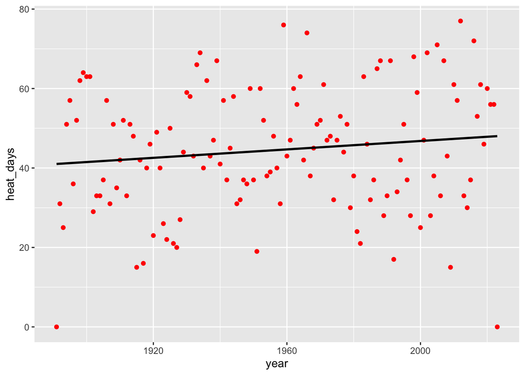

```r
climate$heat <- ifelse(climate$tmax >= 84, 1, 0)

clim_ht_sum <- climate %>%
  group_by(year) %>%
  summarize(heat_days = sum(heat)) %>%
  mutate(year = as.numeric(year))

ggplot(data = clim_ht_sum,
       aes(x = year, y = heat_days)) +
  geom_point(color = "red") +
  geom_smooth(formula = y ~ x,
              color = "black",
              method = "lm",
              se = FALSE)
```

```r
heat_lm <- lm(heat_days ~ year, data = clim_ht_sum)
```

The y-intercept value stands at -59.28 days. The slope for heat days per year is 0.053 and is not statistically significant with a p-value of 0.14.

## Precipitation

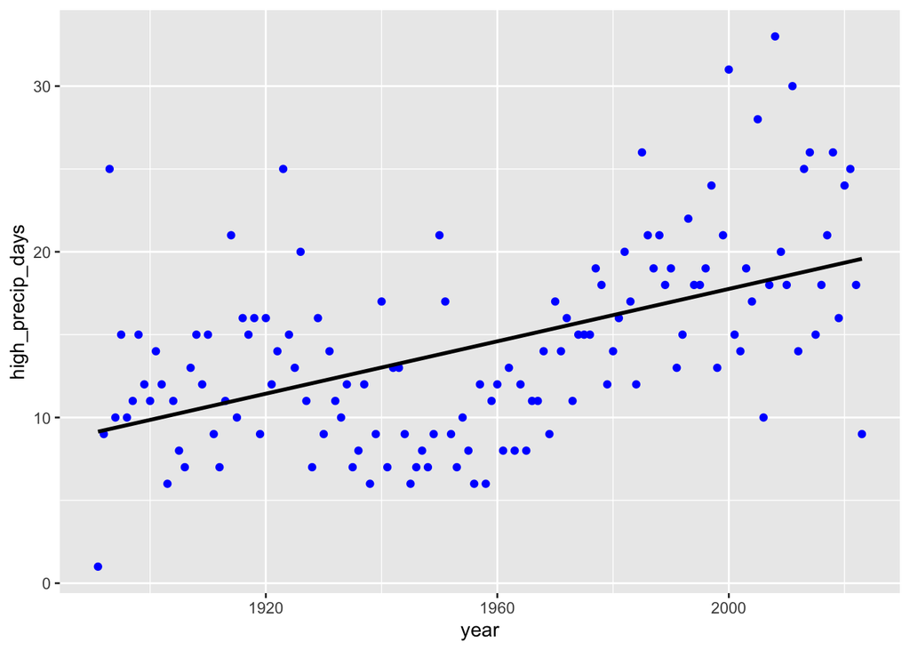

```r
climate$precip <- ifelse(climate$all_prcp >= 1.25, 1, 0)

clim_prcp_sum <- climate %>%
  group_by(year) %>%
  summarize(high_precip_days = sum(precip)) %>%
  mutate(year = as.numeric(year))

ggplot(data = clim_prcp_sum,
       aes(x = year, y = high_precip_days)) +
  geom_point(color = "blue") +
  geom_smooth(formula = y ~ x,
              color = "black",
              method = "lm",
              se = FALSE)
```

```r
all_precip_lm <- lm(high_precip_days ~ year, data = clim_prcp_sum)
```

The y-intercept value stands at -140.31 days. The slope for extreme precipitation days per year is 0.079 and is statistically significant with a p-value of 2.36e-10.

# Data

Great Lakes Integrated Sciences + Assessments (GLISA). (2021). Ann Arbor, MI Climatology [PDF]. Retrieved April 15, 2023, from https://glisa.umich.edu/wp-content/uploads/2021/02/AnnArborMI_Climatology.pdf

NOAA. (2023). Daily Summaries at the Ann Arbor University of Michigan Station. NOAA. https://www.ncei.noaa.gov/cdo-web/datasets/GHCND/stations/GHCND:USC00200230/detail

WeatherSpark. (n.d.). Average Weather in Ann Arbor, Michigan, United States, Year Round. Retrieved April 15, 2023, from https://weatherspark.com/y/16511/Average-Weather-in-Ann-Arbor-Michigan-United-States-Year-Round